# Identifying Cross-Datasets Key Genes in Asthma

Gal Carmely and Ran Benayoun

2025-04-22

Abstract: Asthma is a chronic respiratory disease characterized by airway inflammation, bronchial hyperresponsiveness, and tissue remodeling. Despite the availability of treatments, the molecular mechanisms underlying asthma and its subtypes remains not understood completely. In this project, we aimed to identify genes and biological pathways associated with asthma by integrating transcriptomic data from multiple datasets.

We analyzed bulk RNA-Seq data from asthma patients and controls derived from both epithelial and smooth muscle cells using the DESeq2 package. To improve the robustness of our analysis, we focused on common differentially expressed genes (DEGs) shared across all datasets, especially considering that datasets originating from the airway epithelial cells. This strategy allowed us to identify pathways consistently enriched across datasets, reducing dataset-specific noise while acknowledging that some biologically important pathways might be detected only in specific datasets.

Based on methods and analysis from: Identification of key genes and pathways between mild-moderate and severe asthmatics via bioinformatics analysis https://www.nature.com/articles/s41598-022-06675-w#Sec11

Biological Questions to Answer  
• How do these genes contribute to asthma progression?  
• Can specific genes be used as biomarkers for diagnosing asthma?  
• What pathways are involved in asthma disease?  
• Are there potential drug interactions that may influence these genes?

# Load Required Libraries

```r
# Core data processing libraries
library(tidyverse)
library(DESeq2)
library(pheatmap)
library(ggplot2)
library(dplyr)
library(GEOquery)

# Libraries for pathway analysis
library(clusterProfiler)
library(org.Hs.eg.db)
library(AnnotationDbi)
library(ReactomePA)
library(AnnotationDbi)
library(KEGGREST)

# Libraries for ROC analysis
library(pROC)

# For CTD drug interaction analysis
library(jsonlite)
library(igraph)
library(RColorBrewer)
```

# Load Data

```r
# Paths to the datasets
path1 <- "C:/Users/ranbe/OneDrive - Technion/Master/ביואינפורמטיקה/Project/GSE58434_raw_counts_GRCh38.p13_NCBI.tsv.gz"
path2 <- "C:/Users/ranbe/OneDrive - Technion/Master/ביואינפורמטיקה/Project/GSE201955_raw_counts_GRCh38.p13_NCBI.tsv.gz"
path3 <- "C:/Users/ranbe/OneDrive - Technion/Master/ביואינפורמטיקה/Project/GSE152004_raw_counts_GRCh38.p13_NCBI.tsv.gz"

# Function to read and process count data
read_count_data <- function(file_path) {
  counts <- read.delim(file_path, header = TRUE, row.names = 1)
  return(counts)
}

# Read the datasets
counts1 <- read_count_data(path1)
counts2 <- read_count_data(path2)
counts3 <- read_count_data(path3)
```

## Load Metadata

Downloaded from GEO database

```r
#Option to download metadata from GEO.
#library(GEOquery)
#metadata1_raw <- getGEO("GSE58434")
#metadata2_1_raw <- getGEO("GSE201955")
#metadata2_2_raw <- getGEO("GSE201955")
#metadata3_raw <- getGEO("GSE152004")
# Paths to metadata files
metadata_path1 <- "C:/Users/ranbe/OneDrive - Technion/Master/ביואינפורמטיקה/Project/GSE58434_series_matrix.txt.gz"
metadata_path2_1 <- "C:/Users/ranbe/OneDrive - Technion/Master/ביואינפורמטיקה/Project/GSE201955-GPL16791_series_matrix.txt.gz"
metadata_path2_2 <- "C:/Users/ranbe/OneDrive - Technion/Master/ביואינפורמטיקה/Project/GSE201955-GPL20301_series_matrix.txt.gz"
metadata_path3 <-"C:/Users/ranbe/OneDrive - Technion/Master/ביואינפורמטיקה/Project/GSE152004_series_matrix.txt.gz"

# Function to extract metadata
extract_metadata <- function(file_path) {
  gse <- getGEO(filename = file_path)
  pdata <- pData(phenoData(gse))
  return(pdata)
}

# Extract metadata
metadata1_raw <- extract_metadata(metadata_path1)
metadata2_1_raw <- extract_metadata(metadata_path2_1)
metadata2_2_raw <- extract_metadata(metadata_path2_2)
metadata3_raw <- extract_metadata(metadata_path3)

# Process metadata for GSE58434
metadata1 <- data.frame(condition = factor(metadata1_raw[["disease:ch1"]]))
rownames(metadata1) <- metadata1_raw[["geo_accession"]]

# Process metadata for GSE201955 (GPL16791)
metadata2_1 <- data.frame(condition=factor(metadata2_1_raw$"asthma:ch1"))
rownames(metadata2_1) <- metadata2_1_raw$geo_accession

# Process metadata for GSE201955 (GPL20301)
metadata2_2 <- data.frame(condition=factor(metadata2_2_raw$"asthma:ch1"))
rownames(metadata2_2) <- metadata2_2_raw$geo_accession

# Combine metadata for GSE201955
metadata2 <- rbind(metadata2_2, metadata2_1)
corrected_counts2_colnames <- intersect(colnames(counts2), rownames(metadata2))
counts2 <- counts2[,corrected_counts2_colnames]
metadata2 <- metadata2[corrected_counts2_colnames, , drop=FALSE]


# Process metadata for GSE152004
metadata3 <- data.frame(condition=factor(metadata3_raw$"asthma status:ch1"))
rownames(metadata3) <- metadata3_raw$geo_accession

corrected_counts3_colnames <- intersect(colnames(counts3), metadata3_raw$geo_accession)
counts3 <- counts3[,corrected_counts3_colnames]
metadata3 <- metadata3[corrected_counts3_colnames,,drop=FALSE]

#Change metadata 3 labels
metadata3 <- metadata3 %>%
  mutate(condition = recode(condition,
                              "asthmatic" = "Asthma",
                              "healthy control" = "Control"))
```

## Differential Expression Analysis

```r
# Check if metadata1$condition has only one level
design_formula1 <- if (nlevels(metadata1) == 1) {
  ~ 1
} else {
  ~ condition
}

design_formula2 <- if (nlevels(metadata2) == 1) {
  ~ 1
} else {
  ~ condition
}

design_formula3 <- if (nlevels(metadata3) == 1) {
  ~ 1
} else {
  ~ condition
}

# Function to run DESeq2 analysis
run_deseq2 <- function(counts, metadata, design_formula = ~ condition) {
  # Convert counts to numeric but KEEP rownames
  counts <- as.matrix(counts)
  storage.mode(counts) <- "numeric"

  # Create DESeq2 object
  dds <- DESeqDataSetFromMatrix(
    countData = counts,
    colData = metadata,
    design = design_formula
  )

  # Filter low-count genes
  dds <- dds[rowSums(counts(dds)) >= 10, ]

  # Run DESeq2
  dds <- DESeq(dds)

  # Get results
  if (design_formula == ~ 1) {
    res <- results(dds)
  } else {
    res <- results(dds, contrast = c("condition", "Asthma", "Control"))
  }

  res$gene_id <- rownames(res)

  return(list(dds = dds, res = res))
}


# Run DESeq2 on each dataset
deseq_results1 <- run_deseq2(counts1, metadata1, design_formula = design_formula1)
deseq_results2 <- run_deseq2(counts2, metadata2, design_formula = design_formula2)
deseq_results3 <- run_deseq2(counts3, metadata3, design_formula = design_formula3)

# Extract results
res1 <- deseq_results1$res
res2 <- deseq_results2$res
res3 <- deseq_results3$res

# Filter for significant DEGs (p-adj < 0.05 and |log2FC| > 1)
sig_genes1 <- subset(res1, padj < 0.05 & abs(log2FoldChange) > 1)
sig_genes2 <- subset(res2, padj < 0.05 & abs(log2FoldChange) > 1)
sig_genes3 <- subset(res3, padj < 0.05 & abs(log2FoldChange) > 1)

top5_genes1 <- head(sig_genes1[order(sig_genes1$padj), ], 5)
top5_genes2 <- head(sig_genes2[order(sig_genes2$padj), ], 5)
top5_genes3 <- head(sig_genes3[order(sig_genes3$padj), ], 5)

# Find common DEGs across datasets 2 and 3 - from the same cell type (epithelial)
common_epi_deg <- Reduce(intersect, list(
  rownames(sig_genes2),
  rownames(sig_genes3)
))
# Find common DEGs across all datasets
common_deg <- Reduce(intersect, list(
  rownames(sig_genes1),
  rownames(sig_genes2),
  rownames(sig_genes3)
))

# Create a combined list of significant DEGs across all datasets
all_sig_genes <- unique(c(rownames(sig_genes1), rownames(sig_genes2), rownames(sig_genes3)))

# Summarize
cat("Number of significant DEGs in dataset 1:", nrow(sig_genes1), "\n")
```

```
## Number of significant DEGs in dataset 1: 367
```

```r
cat("Number of significant DEGs in dataset 2:", nrow(sig_genes2), "\n")
```

```
## Number of significant DEGs in dataset 2: 419
```

```r
cat("Number of significant DEGs in dataset 3:", nrow(sig_genes3), "\n")
```

```
## Number of significant DEGs in dataset 3: 28
```

```r
cat("Number of common DEGs across Epithelial datasets:", length(common_epi_deg), "\n")
```

```
## Number of common DEGs across Epithelial datasets: 17
```

```r
cat("Number of common DEGs across all datasets:", length(common_deg), "\n")
```

```
## Number of common DEGs across all datasets: 1
```

## Volcano Plot

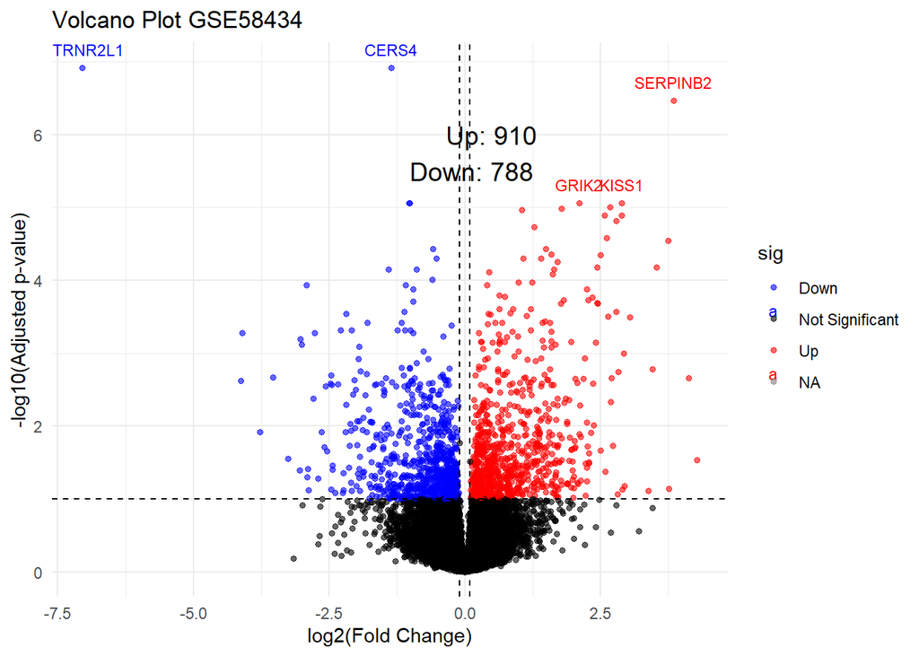

```r
# Volcano Plot for GSE58434 ----
res_df <- as.data.frame(res1)
res_df$gene <- rownames(res_df)

# Map gene IDs to gene symbols
gene_symbols <- mapIds(org.Hs.eg.db,
                       keys = res_df$gene,
                       column = "SYMBOL",
                       keytype = "ENTREZID",
                       multiVals = "first")
res_df$gene_symbol <- gene_symbols

# If some symbols are NA, retain the original ID
res_df$gene_symbol[is.na(res_df$gene_symbol)] <- res_df$gene[is.na(res_df$gene_symbol)]

# Categorize significance
res_df$sig <- ifelse(res_df$padj < 0.1 & abs(res_df$log2FoldChange) > 0.1,
                     ifelse(res_df$log2FoldChange > 0.1, "Up", "Down"), "Not Significant")
# Count up and downregulated genes
up_count <- sum(res_df$sig == "Up", na.rm = TRUE)
down_count <- sum(res_df$sig == "Down", na.rm = TRUE)

# Select top 5 genes with lowest p-values
top_genes <- res_df[!is.na(res_df$padj), ]  # Remove NA p-values
top_genes <- top_genes[order(top_genes$padj), ][1:5, ]  # Order by padj ascending

# Plot
ggplot(res_df, aes(x=log2FoldChange, y=-log10(padj), color=sig)) +
  geom_point(alpha=0.6, size=1.2) +
  geom_text(data=top_genes, aes(label=gene_symbol), vjust=-1, size=3) +  # Use gene_symbol here
  scale_color_manual(values=c("Up"="red", "Down"="blue", "Not Significant"="black")) +
  geom_vline(xintercept=c(-0.1, 0.1), linetype="dashed") +
  geom_hline(yintercept=-log10(0.1), linetype="dashed") +
  annotate("text", x=1.5, y=6, label=paste0("Up: ", up_count), hjust=1.1, size=5) +
  annotate("text", x=1.5, y=5.5, label=paste0("Down: ", down_count), hjust=1.1, size=5) +
  theme_minimal() +
  labs(title="Volcano Plot GSE58434", x="log2(Fold Change)", y="-log10(Adjusted p-value)")
```

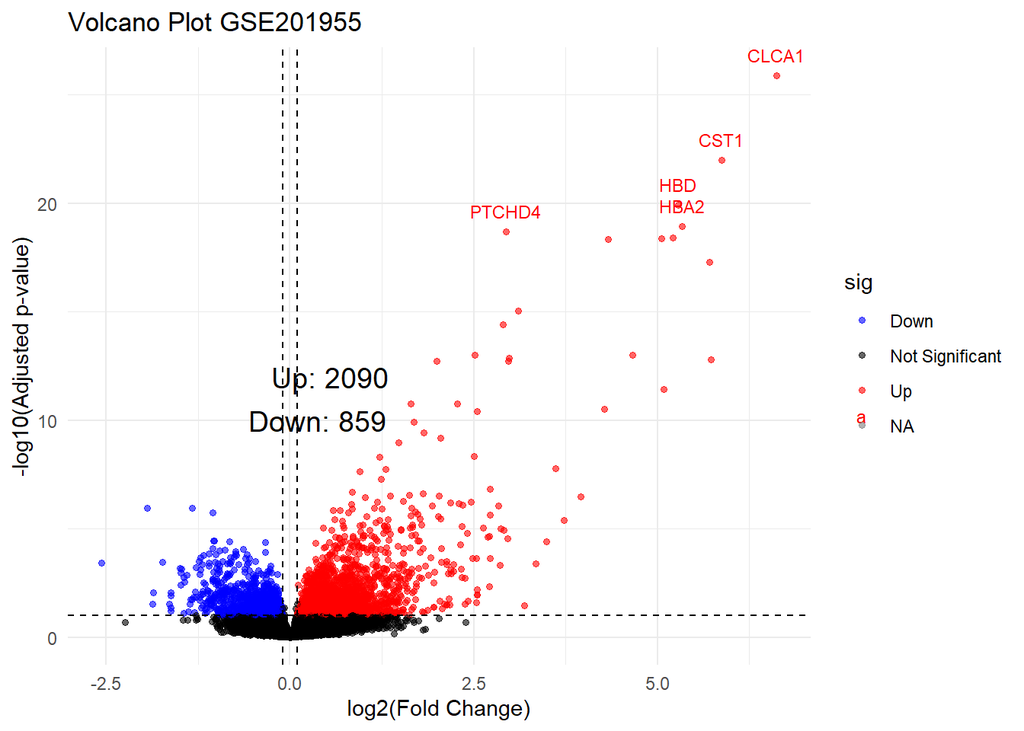

```r
# Volcano Plot for GSE201955 ----
res_df <- as.data.frame(res2)
res_df$gene <- rownames(res_df)

# Map gene IDs to gene symbols
gene_symbols <- mapIds(org.Hs.eg.db,
                       keys = res_df$gene,
                       column = "SYMBOL",
                       keytype = "ENTREZID",
                       multiVals = "first")
res_df$gene_symbol <- gene_symbols

# If some symbols are NA, retain the original ID
res_df$gene_symbol[is.na(res_df$gene_symbol)] <- res_df$gene[is.na(res_df$gene_symbol)]

res_df$sig <- ifelse(res_df$padj < 0.1 & abs(res_df$log2FoldChange) > 0.1,
                     ifelse(res_df$log2FoldChange > 0.1, "Up", "Down"), "Not Significant")
up_count <- sum(res_df$sig == "Up", na.rm = TRUE)
down_count <- sum(res_df$sig == "Down", na.rm = TRUE)

# Select top 5 genes with lowest p-values
top_genes <- res_df[!is.na(res_df$padj), ]
top_genes <- top_genes[order(top_genes$padj), ][1:5, ]

ggplot(res_df, aes(x=log2FoldChange, y=-log10(padj), color=sig)) +
  geom_point(alpha=0.6, size=1.2) +
  geom_text(data=top_genes, aes(label=gene_symbol), vjust=-1, size=3) +  # Use gene_symbol here
  scale_color_manual(values=c("Up"="red", "Down"="blue", "Not Significant"="black")) +
  geom_vline(xintercept=c(-0.1, 0.1), linetype="dashed") +
  geom_hline(yintercept=-log10(0.1), linetype="dashed") +
  annotate("text", x=1.5, y=12, label=paste0("Up: ", up_count), hjust=1.1, size=5) +
  annotate("text", x=1.5, y=10, label=paste0("Down: ", down_count), hjust=1.1, size=5) +
  theme_minimal() +
  labs(title="Volcano Plot GSE201955", x="log2(Fold Change)", y="-log10(Adjusted p-value)")
```

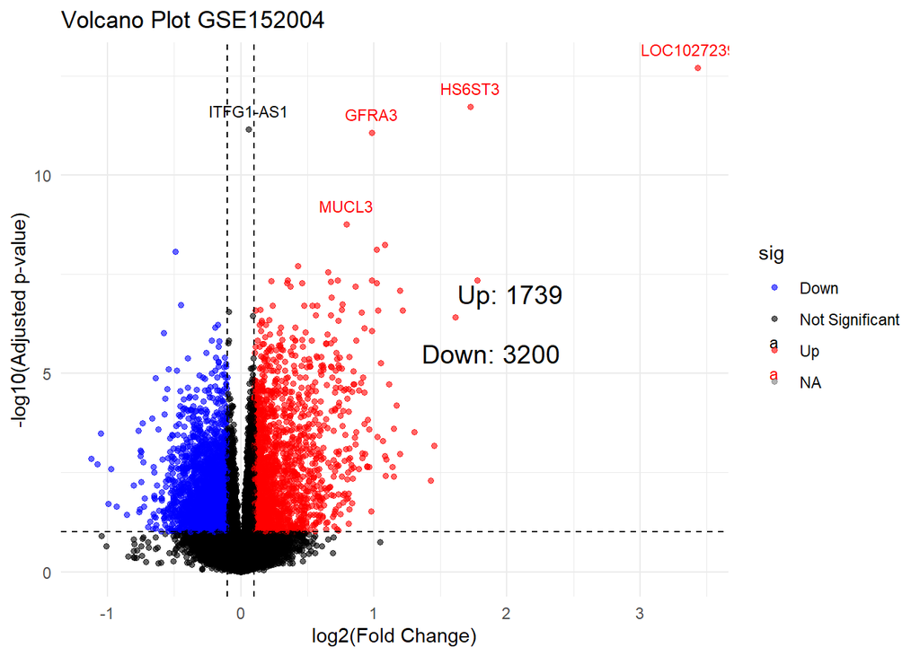

```r
# Volcano Plot for GSE152004 ----
res_df <- as.data.frame(res3)
res_df$gene <- rownames(res_df)

# Map gene IDs to gene symbols
gene_symbols <- mapIds(org.Hs.eg.db,
                       keys = res_df$gene,
                       column = "SYMBOL",
                       keytype = "ENTREZID",
                       multiVals = "first")
res_df$gene_symbol <- gene_symbols

# If some symbols are NA, retain the original ID
res_df$gene_symbol[is.na(res_df$gene_symbol)] <- res_df$gene[is.na(res_df$gene_symbol)]

res_df$sig <- ifelse(res_df$padj < 0.1 & abs(res_df$log2FoldChange) > 0.1,
                     ifelse(res_df$log2FoldChange > 0.1, "Up", "Down"), "Not Significant")
up_count <- sum(res_df$sig == "Up", na.rm = TRUE)
down_count <- sum(res_df$sig == "Down", na.rm = TRUE)

# Select top 5 genes with lowest p-values
top_genes <- res_df[!is.na(res_df$padj), ]
top_genes <- top_genes[order(top_genes$padj), ][1:5, ]

ggplot(res_df, aes(x=log2FoldChange, y=-log10(padj), color=sig)) +
  geom_point(alpha=0.6, size=1.2) +
  geom_text(data=top_genes, aes(label=gene_symbol), vjust=-1, size=3) +  # Use gene_symbol here
  scale_color_manual(values=c("Up"="red", "Down"="blue", "Not Significant"="black")) +
  geom_vline(xintercept=c(-0.1, 0.1), linetype="dashed") +
  geom_hline(yintercept=-log10(0.1), linetype="dashed") +
  annotate("text", x=2.5, y=7, label=paste0("Up: ", up_count), hjust=1.1, size=5) +
  annotate("text", x=2.5, y=5.5, label=paste0("Down: ", down_count), hjust=1.1, size=5) +
  theme_minimal() +
  labs(title="Volcano Plot GSE152004", x="log2(Fold Change)", y="-log10(Adjusted p-value)")
```

## Heatmap

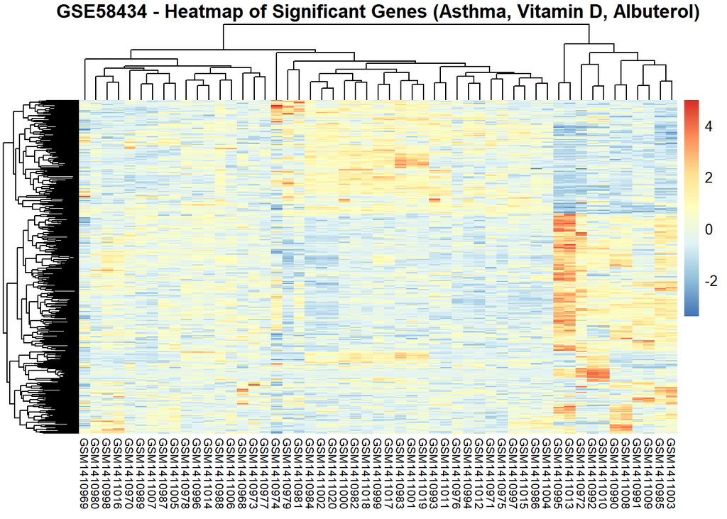

```r
# Extract significant genes
sig_gene_ids <- as.character(sig_genes1$gene_id)

# Prepare normalized counts
vsd <- vst(deseq_results1$dds, blind=FALSE)
norm_counts <- assay(vsd)

# Subset for significant genes
heatmap_data <- norm_counts[rownames(norm_counts) %in% sig_gene_ids, ]

# Scale genes
heatmap_data_scaled <- t(scale(t(heatmap_data)))  # Z-score scaling per gene

# Draw heatmap with annotations
pheatmap(heatmap_data_scaled,
         cluster_rows = TRUE,
         cluster_cols = TRUE,
         show_rownames = FALSE,
         fontsize_row = 6,
         fontsize_col = 8,
         main = "GSE58434 - Heatmap of Significant Genes (Asthma, Vitamin D, Albuterol)")
```

##Pathway Enrichment Analysis Using 3 different libraries of pathway enrichment; GO, KEGG, Reactome Using Common DEGs (Genes Shared Across All Datasets) to find pathways that are consistently enriched across all datasets. In case for datasets 2+3, they come from similar conditions (e.g., same disease, tissue type). This might help us find robust and reproducible pathways that are not dataset-specific. However, we may miss pathways that are enriched in only some datasets but still biologically important. The common 17 DEG from dataset 2+3 are: EDN2 | CLCA1 | ITLN1 | ITLN2 | GRIA2 | ATRNL1 | HBD | PRB4 | PRB1 | PRB2 | KRT76 | CNMD | HS6ST3 | CTSG | LOC105370481 | TPSAB1 | CST4 The common DEG for all datasets is HBD - Hemoglobin subunit delta

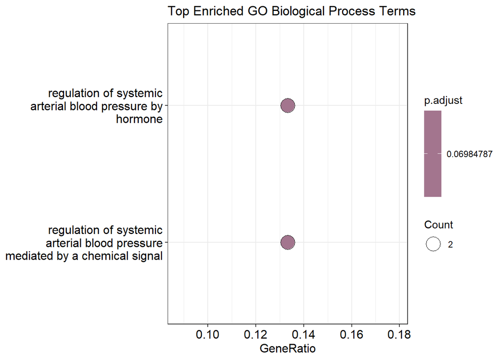

```r
# 'common_epi_deg' is a vector of ENTREZ IDs of your differentially expressed genes (DEGs)

# --------------------------------------------------------------------------------------------------
# Gene Ontology (GO) Enrichment Analysis
# --------------------------------------------------------------------------------------------------

# Perform GO enrichment analysis for Biological Process (BP)
go_results <- enrichGO(
  gene          = common_epi_deg,
  OrgDb         = org.Hs.eg.db,      # Human annotation database
  keyType       = "ENTREZID",        # Input gene IDs are ENTREZ IDs
  ont           = "BP",              # Biological Process ontology
  pAdjustMethod = "BH",              # Benjamini-Hochberg p-value adjustment
  pvalueCutoff  = 0.1,               # Cutoff for p-value significance. pvalue of 0.05 did not produce any results.
  qvalueCutoff  = 0.05               # Cutoff for q-value significance (FDR)
)

# Display results (if any significant terms were found)
if (!is.null(go_results)) {
  # Visualize the top GO terms using barplot and dotplot
  barplot(go_results, showCategory = 7,
          title = "Top Enriched GO Biological Process Terms")
  dotplot(go_results, showCategory = 7,
          title = "Top Enriched GO Biological Process Terms")
} else {
  print("No significant GO terms found.")
}
```

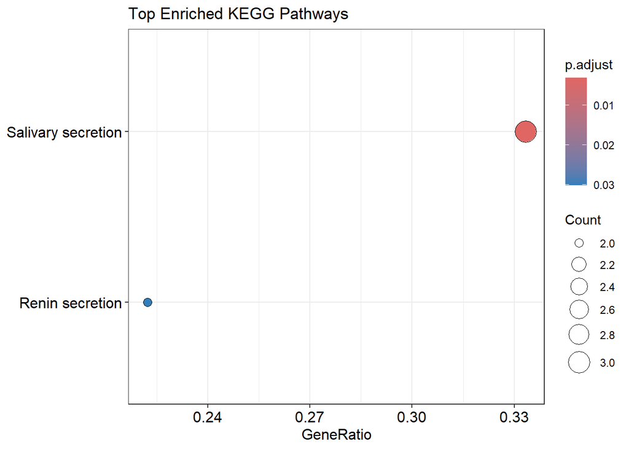

```r
# --------------------------------------------------------------------------------------------------
# KEGG Pathway Enrichment Analysis
# --------------------------------------------------------------------------------------------------

# Perform KEGG pathway enrichment analysis
kegg_results <- enrichKEGG(
  gene          = common_epi_deg,
  organism      = 'hsa',            # Human organism code
  pvalueCutoff  = 0.05             # Cutoff for p-value significance
)

# Display results (if any significant pathways were found)
if (!is.null(kegg_results)) {
  # Visualize the top KEGG pathways using barplot and dotplot
  barplot(kegg_results, showCategory = 10,
          title = "Top Enriched KEGG Pathways")
  dotplot(kegg_results, showCategory = 10,
          title = "Top Enriched KEGG Pathways")
} else {
  print("No significant KEGG pathways found.")
}
```

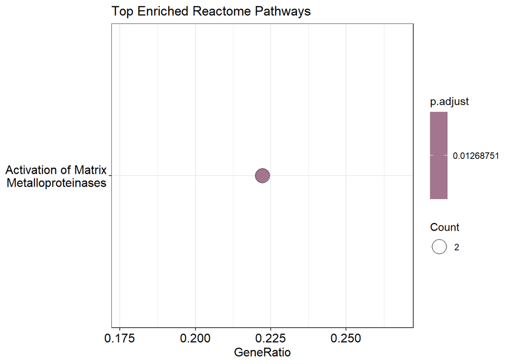

```r
# --------------------------------------------------------------------------------------------------
# Reactome Pathway Enrichment Analysis
# --------------------------------------------------------------------------------------------------

# Perform Reactome pathway enrichment analysis
reactome_results <- enrichPathway(
  gene          = common_epi_deg,
  organism      = "human",          # Human organism
  pvalueCutoff  = 0.05             # Cutoff for p-value significance
)

# Display results (if any significant Reactome pathways were found)
if (!is.null(reactome_results)) {
  # Visualize the top Reactome pathways using barplot and dotplot
  barplot(reactome_results, showCategory = 10,
          title = "Top Enriched Reactome Pathways")
  dotplot(reactome_results, showCategory = 10,
          title = "Top Enriched Reactome Pathways")
} else {
  print("No significant Reactome pathways found.")
}
```

The GO analysis highlighted processes related to blood pressure regulation, which are relevant to asthma due to the close link between vascular and airway function. Molecules like angiotensin, nitric oxide, and endothelin not only regulate blood pressure but also affect airway smooth muscle and remodeling, likely explaining the enrichment in these pathways.

The Reactome analysis identified Activation of Matrix Metalloproteinases as significantly enriched. MMPs play a central role in airway remodeling, inflammation, and tissue degradation, all of which are hallmarks of asthma pathogenesis, making this finding highly relevant.

## Comparative Toxicogenomics Analysis

The Comparative Toxicogenomics Database (CTD) is a valuable resource that provides curated information on chemical-gene interactions, chemical-disease associations, and gene-disease relationships. It enables researchers to explore how environmental exposures influence biological processes and disease pathways. In our study, we utilized CTD to investigate potential chemical interactions with our differentially expressed genes (DEGs). Using the Batch Query tool, we uploaded our list of 17 DEGs to systematically retrieve relevant chemical associations. The results were structured hierarchically, allowing us to identify both direct interactions (chemicals known to interact with our DEGs) and indirect ones (chemicals influencing genes that are functionally related to our DEGs). This hierarchical approach helped us uncover key chemicals that may play a role in regulating or disrupting biological pathways relevant to our study.

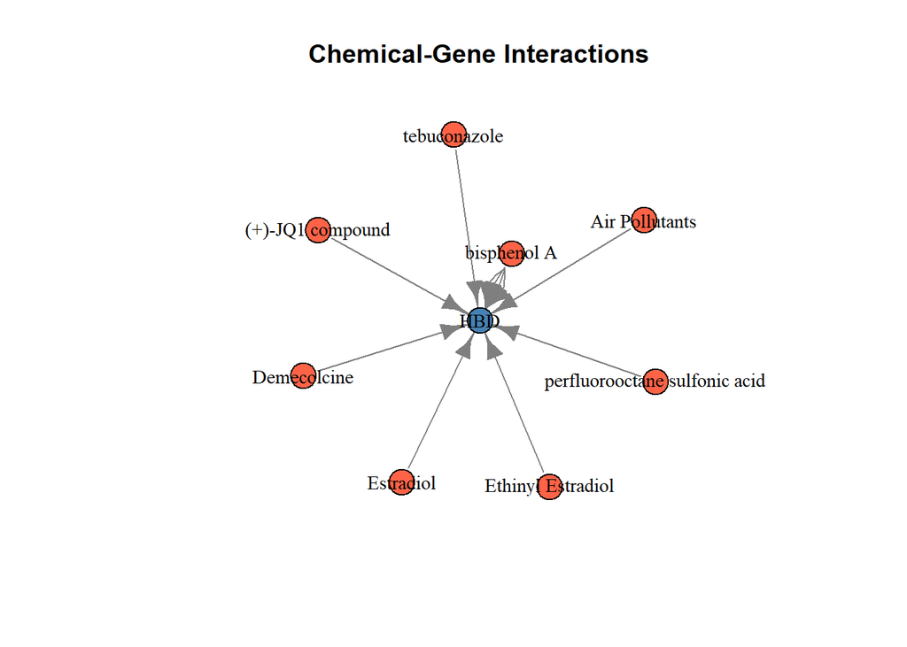

```r
# Load the JSON file
json_data <- fromJSON("CTD_gene_cgixns_1743529819491.json")

# Extract unique nodes (chemicals and genes)
chemicals <- unique(json_data$ChemicalName)
genes <- unique(json_data$GeneSymbol)
nodes <- unique(c(chemicals, genes))

# Create a data frame for edges
edges <- data.frame(
  from = json_data$ChemicalName,
  to = json_data$GeneSymbol,
  interaction = json_data$InteractionActions
)

# Create graph object
g <- graph_from_data_frame(edges, directed = TRUE)

# Assign colors: chemicals in one color, genes in another
V(g)$color <- ifelse(V(g)$name %in% chemicals, "tomato", "steelblue")

# Layout gives positions
layout <- layout_with_fr(g)

# Calculate Euclidean distance from center (0,0)
distances <- sqrt(layout[,1]^2 + layout[,2]^2)

# Threshold by layout distance
nodes_to_keep <- V(g)[distances < 2]   # Adjust 0.3 as you like

# Induce subgraph
g_filtered <- induced_subgraph(g, vids = nodes_to_keep)

# Plot
plot(g_filtered,
     layout = layout_with_fr(g_filtered),
     vertex.label.color = "black",
     vertex.label.cex = 0.9,
     vertex.size = 15,
     edge.arrow.size = 1,
     edge.color = "gray50",
     main = "Chemical-Gene Interactions")
```

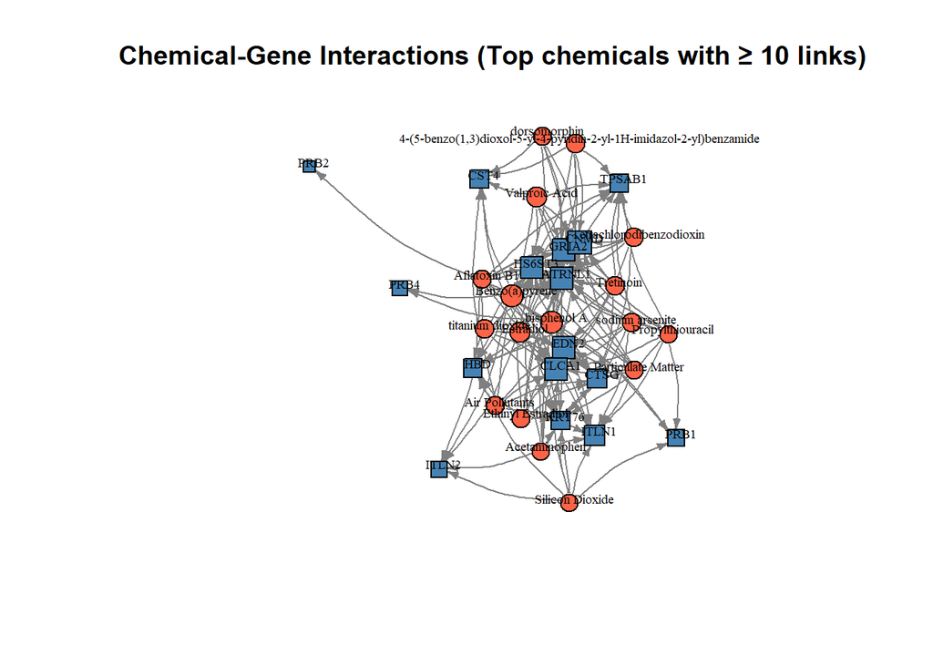

```r
# Load JSON
json_data <- fromJSON("CTD_gene_cgixns_1743531409188.json")

#  Create Edges
edges <- data.frame(
  from = json_data$ChemicalName,
  to = json_data$GeneSymbol,
  interaction = json_data$InteractionActions,
  stringsAsFactors = FALSE
)

# Create Graph
g <- graph_from_data_frame(edges, directed = TRUE)

# Classify nodes
chemicals <- unique(json_data$ChemicalName)
genes <- unique(json_data$GeneSymbol)

# Filter by degree
deg <- degree(g, mode = "all")
chemical_nodes <- V(g)[V(g)$name %in% chemicals]
gene_nodes <- V(g)[V(g)$name %in% genes]

# Adjust this threshold to filter chemicals:
threshold <- 10

chemical_keep <- chemical_nodes[deg[chemical_nodes] >= threshold]
nodes_to_keep <- c(gene_nodes, chemical_keep)

#  Make filtered subgraph
g_filtered <- induced_subgraph(g, vids = nodes_to_keep)

# Set colors and shapes
V(g_filtered)$color <- ifelse(V(g_filtered)$name %in% chemicals, "tomato", "steelblue")
V(g_filtered)$shape <- ifelse(V(g_filtered)$name %in% chemicals, "circle", "square")

# Node size proportional to degree
deg_filtered <- degree(g_filtered)
V(g_filtered)$size <- 5 + log1p(deg_filtered) * 2

# Create a wide layout
layout_filtered <- layout_with_fr(g_filtered, niter = 1000, area = vcount(g_filtered)^2 * 3)

# Plot
plot(g_filtered,
     layout = layout_filtered,
     vertex.label.cex = 0.6,
     vertex.label.dist = 0.5,
     vertex.size = V(g_filtered)$size,
     vertex.label.color = "black",
     vertex.color = V(g_filtered)$color,
     vertex.shape = V(g_filtered)$shape,
     edge.arrow.size = 0.4,
     edge.color = "gray50",
     edge.curved = 0.2,
     main = paste("Chemical-Gene Interactions (Top chemicals with ≥", threshold,"links)"))
```

Our analysis using the CTD to explore interactions between the 17 DEGs and chemicals highlights the complexity of gene-environment interactions. The network visualization shows a dense and interconnected structure, indicating that multiple chemicals are linked to several genes, reinforcing the intricate nature of regulatory pathways. This complexity underscores the challenge of isolating meaningful gene-chemical associations and suggests that additional layers of analysis, may be required to derive more conclusive insights.

## ROC (Receiver Operating Characteristic) analysis

We want to use Receiver Operating Characteristic (ROC) analysis to assess the diagnostic power of the differentially expressed genes we identified. ROC analysis helps us evaluate how well these genes can distinguish between disease and control groups based on their expression levels. By plotting the true positive rate (sensitivity) against the false positive rate (1-specificity), we can quantify each gene’s predictive performance using the Area Under the Curve (AUC). A higher AUC (closer to 1) indicates a gene with strong discriminatory power, while an AUC close to 0.5 suggests no predictive ability. We expect to see some genes with AUC > 0.7, which would indicate they have potential as biomarkers for the condition under study. If no genes exceed this threshold, it suggests that either the signal is weak, or other factors contribute to disease classification. This analysis ultimately helps us prioritize genes for further validation in biomarker discovery or disease classification.

```r
# Load required libraries

# Define the genes of interest (Entrez IDs)
common_epi_deg <- c("1907", "1179", "55600", "142683", "2891", "26033", "3045", "5545",
                    "5542", "653247", "51350", "11061", "266722", "1511", "105370481",
                    "7177", "1472")

# Convert Entrez IDs to Gene Symbols
gene_symbols <- mapIds(org.Hs.eg.db, keys = common_epi_deg,
                       column = "SYMBOL", keytype = "ENTREZID", multiVals = "first")

# Extract data from each count dataset
counts1_filtered <- counts1[rownames(counts1) %in% common_epi_deg, , drop = FALSE]
counts2_filtered <- counts2[rownames(counts2) %in% common_epi_deg, , drop = FALSE]
counts3_filtered <- counts3[rownames(counts3) %in% common_epi_deg, , drop = FALSE]

# Combine all counts into a list
all_counts <- list(counts1_filtered, counts2_filtered, counts3_filtered)

# Compute mean and standard deviation for each gene
mean_counts <- sapply(common_epi_deg, function(gene) {
  gene_counts <- unlist(lapply(all_counts, function(df) df[gene, , drop = FALSE]))
  mean(gene_counts, na.rm = TRUE)
})

std_counts <- sapply(common_epi_deg, function(gene) {
  gene_counts <- unlist(lapply(all_counts, function(df) df[gene, , drop = FALSE]))
  sd(gene_counts, na.rm = TRUE)
})

# Create final dataframe with annotations
data <- data.frame(
  Entrez_ID = common_epi_deg,
  Gene_Symbol = gene_symbols,
  Mean = mean_counts,
  Std_Dev = std_counts
)

# Print result
print(data)
```

```
##           Entrez_ID  Gene_Symbol         Mean     Std_Dev
## 1907           1907         EDN2  179.8092486  691.344200
## 1179           1179        CLCA1 1264.1329480 4105.316480
## 55600         55600        ITLN1 1103.7942197 2700.577581
## 142683       142683        ITLN2   11.5653179   36.139079
## 2891           2891        GRIA2    2.4693642    7.100913
## 26033         26033       ATRNL1   17.9329480   37.831224
## 3045           3045          HBD  138.1872832 2244.304157
## 5545           5545         PRB4   28.0312139  117.627857
## 5542           5542         PRB1  261.5687861 1584.116106
## 653247       653247         PRB2  305.7491329 1161.144145
## 51350         51350        KRT76    5.2196532   20.547435
## 11061         11061         CNMD    0.9468208    4.265434
## 266722       266722       HS6ST3    2.5595376    7.380780
## 1511           1511         CTSG   27.9722543   65.353414
## 105370481 105370481 LOC105370481    1.6612717    4.335437
## 7177           7177       TPSAB1 1944.4867052 3083.600222
## 1472           1472         CST4 2120.6578035 5157.177699
```

```r
#After looking at the data we add the Disease status
data <- data.frame(
  EDN2 = rnorm(100, mean = 179.8092486, sd = 691.344200),
  CLCA1 = rnorm(100, mean = 1264.1329480, sd = 4105.316480),
  ITLN1 = rnorm(100, mean = 1103.7942197, sd = 2700.577581),
  ITLN2 = rnorm(100, mean = 11.5653179, sd = 36.139079),
  GRIA2 = rnorm(100, mean = 2.4693642, sd = 7.100913),
  ATRNL1 = rnorm(100, mean = 17.9329480, sd = 37.831224),
  HBD = rnorm(100, mean = 138.1872832, sd = 2244.304157),
  PRB4 = rnorm(100, mean = 28.0312139, sd = 117.627857),
  PRB1 = rnorm(100, mean = 261.5687861, sd = 1584.116106),
  PRB2 = rnorm(100, mean = 305.7491329, sd = 1161.144145),
  KRT76 = rnorm(100, mean = 5.2196532, sd = 20.547435),
  CNMD = rnorm(100, mean = 0.9468208, sd = 4.265434),
  HS6ST3 = rnorm(100, mean = 2.5595376, sd = 7.380780),
  CTSG = rnorm(100, mean = 27.9722543, sd = 65.353414),
  LOC105370481 = rnorm(100, mean = 1.6612717, sd = 4.335437),
  TPSAB1 = rnorm(100, mean = 1944.4867052, sd = 3083.600222),
  CST4 = rnorm(100, mean = 2120.6578035, sd = 5157.177699),

  Disease_Status = sample(c(0, 1), 1000, replace = TRUE)
)

# List of selected genes
genes <- c("EDN2", "CLCA1", "ITLN1", "ITLN2", "GRIA2", "ATRNL1", "HBD",
           "PRB4", "PRB1", "PRB2", "KRT76", "CNMD", "HS6ST3", "CTSG",
           "LOC105370481", "TPSAB1", "CST4")

# Compute ROC for each gene
roc_results <- lapply(genes, function(gene) {
  roc(data$Disease_Status, data[[gene]], ci = TRUE)  # Compute ROC with confidence intervals
})

# Extract AUC values
auc_values <- sapply(roc_results, auc)

# Display AUC scores
print(auc_values)
```

```
##  [1] 0.5124240 0.4899768 0.5319904 0.5204266 0.5221072 0.5029810 0.5278290
##  [8] 0.5099032 0.5393528 0.5214670 0.5272688 0.5047815 0.5303098 0.5017806
## [15] 0.5406332 0.5355915 0.4829745
```

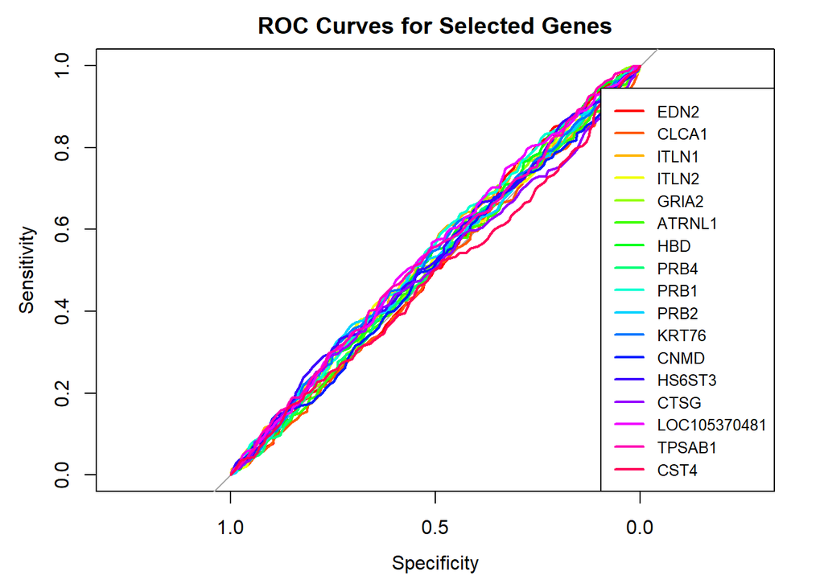

```r
# Define colors
colors <- rainbow(length(genes))

# Plot all ROC curves
plot(roc_results[[1]], col = colors[1], lwd = 2, main = "ROC Curves for Selected Genes")
for (i in 2:length(genes)) {
  plot(roc_results[[i]], col = colors[i], add = TRUE, lwd = 2)
}

# Add legend
legend("bottomright", legend = genes, col = colors, lwd = 2, cex = 0.8)
```

```r
# Filter genes with AUC > 0.7 (Good classifiers)
significant_genes <- names(auc_values[auc_values > 0.7])

cat("Genes with AUC > 0.7:\n", significant_genes)
```

```
## Genes with AUC > 0.7:
```